# Wrappers do `ggplot2` que já aplicam tema, paleta e formatação do guia automaticamente. Abaixo mostro como chamar cada um, com exemplos mínimos.

# 8 🍩 Pizza & Rosca

**Quando usar:** para ilustrar a divisão de um todo em poucas partes (até 4–6 categorias), facilitando a visualização de proporções simples.

**Dica:** reserve a cor cinza para agrupar fatias menores em “Outros” e considere a versão em rosca quando quiser adicionar texto ou valores no centro.

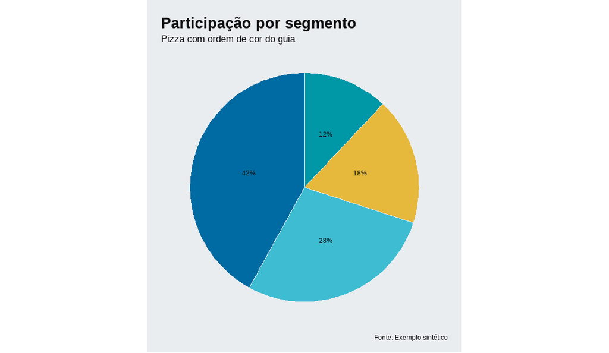

```r
# Helper para rótulos SI (substitui label_number_si())
label_si_br <- scales::label_number(
  scale_cut    = scales::cut_short_scale(),
  big.mark     = ".",
  decimal.mark = ","
)

econ_pie <- function(data, cat, val, type = c("pie","doughnut"),
                     top_n = NULL, other_label = "Outros",
                     show_labels = TRUE, label_kind = c("percent","value","both"),
                     min_pct_label = 0.06, hole_text = NULL,
                     start = 0, direction = 1,
                     title = NULL, subtitle = NULL, caption = "Fonte: Exemplo sintético") {
  type <- match.arg(type); label_kind <- match.arg(label_kind)
  df <- as_tibble(data) %>%
    group_by({{cat}}) %>%
    summarise(valor = sum({{val}}, na.rm = TRUE), .groups = "drop") %>%
    arrange(desc(valor))
  if (!is.null(top_n) && nrow(df) > top_n) {
    df <- bind_rows(
      df %>% slice(1:top_n),
      tibble(`{{cat}}` := other_label,
             valor = sum(df$valor[(top_n+1):nrow(df)], na.rm = TRUE))
    )
    names(df)[1] <- rlang::as_name(rlang::enquo(cat))
  }
  total <- sum(df$valor)
  df <- df %>%
    mutate(pct = valor/total,
           lab = case_when(
             label_kind == "percent" ~ label_percent(accuracy = 1)(pct),
             label_kind == "value"   ~ label_number(big.mark=".", decimal.mark=",")(valor),
             TRUE ~ paste0(label_percent(accuracy = 1)(pct), " (",
                           label_number(big.mark=".", decimal.mark=",")(valor), ")")
           ),
           cat_f = forcats::fct_inorder(!!rlang::enquo(cat)))
  pal <- econ_pie_order6
  if (any(df[[1]] %in% other_label, na.rm = TRUE)) pal <- c(pal, econ_base$grid)
  pal <- rep(pal, length.out = length(levels(df$cat_f))); names(pal) <- levels(df$cat_f)
  base_theme <- theme_void(base_family = font_family) +
    theme(plot.background  = element_rect(fill = econ_base$bg, colour = NA),
          panel.background = element_rect(fill = econ_base$bg, colour = NA),
          legend.position = "none",
          plot.title    = element_text(face = "bold", size = 20, hjust = 0, colour = econ_base$text),
          plot.subtitle = element_text(size = 12.5, hjust = 0, colour = econ_base$text),
          plot.caption  = element_text(size = 9,  hjust = 1, colour = econ_base$text),
          plot.margin   = margin(16,16,14,16))
  if (type == "pie") {
    g <- ggplot(df, aes(x = 1, y = valor, fill = cat_f)) +
      geom_col(width = 1, colour = econ_base$bg, linewidth = 0.6) +
      coord_polar(theta = "y", start = start, direction = direction) +
      scale_fill_manual(values = pal) + base_theme +
      labs(title = title, subtitle = subtitle, caption = caption)
  } else {
    g <- ggplot(df, aes(x = 2, y = valor, fill = cat_f)) +
      geom_col(width = 1, colour = econ_base$bg, linewidth = 0.6) +
      coord_polar(theta = "y", start = start, direction = direction) +
      xlim(0.5, 2.5) +
      scale_fill_manual(values = pal) + base_theme +
      labs(title = title, subtitle = subtitle, caption = caption)
    if (!is.null(hole_text)) {
      g <- g + annotate("text", x = 0, y = 0, label = hole_text,
                        family = font_family, colour = econ_base$text,
                        size = 4, lineheight = 1.05, fontface = "bold")
    }
  }
  if (show_labels) {
    g <- g + geom_text(
      data = df %>% filter(pct >= min_pct_label),
      aes(label = lab),
      position = position_stack(vjust = 0.5),
      family = font_family, size = 3.2, colour = econ_base$text
    )
  }
  g
}

# Exemplo — pizza
df_pie <- tibble(
  categoria = c("A","B","C","D"),
  valor = c(42, 28, 18, 12)
)
econ_pie(
  df_pie, cat = categoria, val = valor,
  type = "pie",
  title = "Participação por segmento",
  subtitle = "Pizza com ordem de cor do guia"
)
```

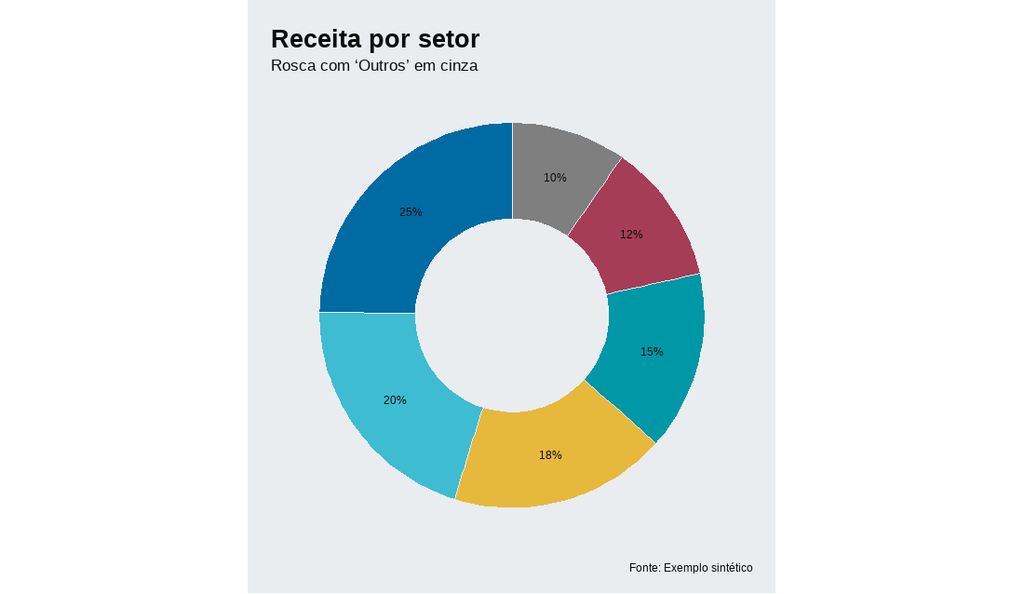

```r
# Exemplo — rosca com “Outros”
df_donut <- tibble(
  setor = c("Automotivo","Tecnologia","Serviços","Energia","Varejo","Outros nichos"),
  v     = c(23, 19, 17, 14, 11, 9)
)
econ_pie(
  df_donut, cat = setor, val = v,
  type = "doughnut", top_n = 5,
  hole_text = paste0("Total\n", label_si_br(sum(df_donut$v))),
  title = "Receita por setor",
  subtitle = "Rosca com ‘Outros’ em cinza"
)
```

# 9 🕒 Timelines (linhas + períodos + eventos)

**Quando usar:** para mostrar a evolução de uma ou mais séries ao longo do tempo, destacando períodos e eventos relevantes que ajudam a contextualizar as mudanças observadas.

**Dica:** use faixas alternadas para marcar diferentes eras e setas finas para indicar eventos, mantendo os rótulos curtos e objetivos para evitar poluição visual.

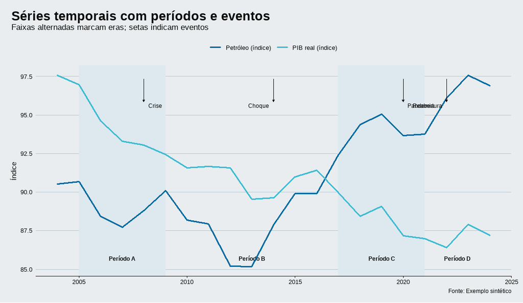

```r
.make_alternating <- function(n) rep(c(TRUE, FALSE), length.out = n)

econ_timeline_data <- function(data, x, y, series = NULL,
                               periods = NULL, events  = NULL,
                               labels = list(title=NULL, subtitle=NULL, x=NULL, y=NULL, caption="Fonte: Exemplo sintético"),
                               format_y = c("number","percent","si"),
                               linewidth = 1.1, legend = TRUE) {
  format_y <- match.arg(format_y)
  y_vec <- dplyr::pull(data, {{y}}); yr <- range(y_vec, na.rm = TRUE)
  dy <- diff(yr); y_top <- yr[2]; y_bot <- yr[1]
  p <- ggplot()
  if (!is.null(periods) && nrow(periods) > 0) {
    per_df <- as_tibble(periods) %>%
      mutate(shade = .make_alternating(n()), xmid  = (start + end) / 2)
    p <- p +
      geom_rect(data = filter(per_df, shade),
                aes(xmin = start, xmax = end, ymin = -Inf, ymax = Inf),
                inherit.aes = FALSE,
                fill = econ_colors$background["highlight"], colour = NA) +
      geom_text(data = per_df,
                aes(x = xmid, y = y_bot + 0.04*dy, label = label),
                inherit.aes = FALSE,
                family = font_family, size = 3.2, fontface = "bold",
                colour = econ_base$text)
  }
  aes_line <- if (rlang::quo_is_null(rlang::enquo(series))) aes({{x}}, {{y}})
              else aes({{x}}, {{y}}, colour = {{series}})
  p <- p + geom_line(data = data, mapping = aes_line, linewidth = linewidth, lineend = "round")
  if (!rlang::quo_is_null(rlang::enquo(series))) p <- p + scale_colour_manual(values = econ_line_order6)
  if (!is.null(events) && nrow(events) > 0) {
    ev_df <- as_tibble(events) %>%
      mutate(y0 = y_top - 0.02*dy, y1 = y_top - 0.14*dy,
             hjust = rep(c(0,1), length.out = n()), xlab  = date + ifelse(hjust == 0, 0.2, -0.2))
    p <- p +
      geom_segment(data = ev_df,
                   aes(x = date, xend = date, y = y0, yend = y1),
                   inherit.aes = FALSE, linewidth = 0.4,
                   arrow = grid::arrow(length = grid::unit(3, "pt"), type = "closed"),
                   colour = econ_base$text) +
      geom_text(data = ev_df,
                aes(x = xlab, y = y1 - 0.02*dy, label = label, hjust = hjust),
                inherit.aes = FALSE, family = font_family, size = 3.2, colour = econ_base$text)
  }
  if (format_y == "percent") p <- p + scale_y_continuous(labels = label_percent())
  if (format_y == "si")      p <- p + scale_y_continuous(labels = label_number(scale_cut = cut_short_scale()))
  if (!legend) p <- p + guides(colour = "none")
  p + theme_econ_base() +
    labs(title = labels$title, subtitle = labels$subtitle,
         x = labels$x, y = labels$y, caption = labels$caption)
}

# Exemplo — timeline com 2 séries, períodos e eventos
set.seed(10)
anos <- 2004:2024
df_ts <- tibble(
  ano = rep(anos, 2),
  serie = rep(c("Petróleo (índice)","PIB real (índice)"), each = length(anos)),
  valor = c(
    90 + cumsum(rnorm(length(anos), 0.5, 2)),
    100 + cumsum(rnorm(length(anos), 0.2, 1.2))
  )
)
periodos <- tibble(
  start = c(2005, 2009, 2017, 2021),
  end   = c(2009, 2017, 2021, 2024),
  label = c("Período A","Período B","Período C","Período D")
)
eventos <- tibble(
  date = c(2008, 2014, 2020, 2022),
  label= c("Crise","Choque","Pandemia","Reabertura")
)
econ_timeline_data(
  df_ts, x = ano, y = valor, series = serie,
  periods = periodos, events = eventos,
  labels = list(
    title = "Séries temporais com períodos e eventos",
    subtitle = "Faixas alternadas marcam eras; setas indicam eventos",
    x = NULL, y = "Índice", caption = "Fonte: Exemplo sintético"
  )
)
```

```r
# Exemplo — timeline simples (1 série)
set.seed(99)
df_ts1 <- tibble(ano = anos, valor = 50 + cumsum(rnorm(length(anos), 0.3, 1.5)))
eventos2 <- tibble(date = c(2007, 2012, 2019),
                   label = c("Mudança\nregulatória","Novo\nproduto","Aquisição"))
econ_timeline_data(
  df_ts1, x = ano, y = valor, series = NULL,
  periods = periodos[2:4,], events = eventos2, legend = FALSE,
  labels = list(
    title = "Timeline de dados (1 série)",
    subtitle = "Eventos com rótulos curtos; sem legenda",
    x = NULL, y = "Índice", caption = "Fonte: Exemplo sintético"
  )
)
```

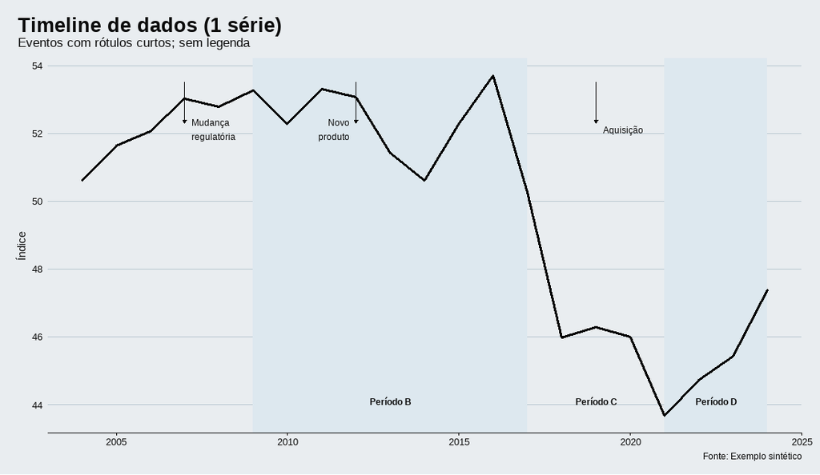